# ETC1010/5510 Tutorial 8 - Solution

Introduction to Data Analysis

Author

Patrick Li

Published

September 9, 2024

## 🎯 Workshop Objectives

- Introduction to web scraping
- Introduction to functions
- Using functions to perform web scraping

## 🔧 Instructions

1. In each question, you will replace ’___’ with your answer. Please note that the Qmd will not knit until you’ve answered all of the questions.
2. Once you have filled up all the blanks, remember to go to `knitr::opts_chunk` at the top of the document, change `eval = TRUE`, then knit the document.

## Exercise 8A: Web Scraping + Data Analysis

### Loading necessary packages

```r
library(tidyverse)
library(rvest)
library(polite)
library(here)
```

#### 1.Introduction

Scrape the IMDb top movies chart, and store the movie titles, year and rank.

We will use the Google extension SelectorGadget to highlight the web page elements, so you can see what the corresponding `html_elements()` parameter should be.

- Install the Chrome extension SelectorGadget:

https://chrome.google.com/webstore/detail/selectorgadget/mhjhnkcfbdhnjickkkdbjoemdmbfginb

#### 2. Scrape the top movies off IMDb. Note that the `html_elements()` correspond with the section of the page that we are going to extract.

```r
page <- read_html("https://web.archive.org/web/20220919144917/https://www.imdb.com/chart/top/")

titles <- page %>%
  html_elements(".titleColumn a") %>%
  html_text2()

years <- page %>%
  html_elements(".secondaryInfo") %>%
  html_text2() %>%
  # Remove "("
  str_remove("\\(") %>%
  # Remove ")"
  str_remove("\\)") %>%
  as.numeric()

scores <- page %>%
  html_elements(".imdbRating strong") %>%
  html_text2() %>%
  as.numeric()

imdb_top_250 <- tibble(title = titles,
                       year = years,
                       score = scores)

imdb_top_250
```

```
# A tibble: 250 × 3
   title                                              year score
   <chr>                                             <dbl> <dbl>
 1 The Shawshank Redemption                           1994   9.2
 2 The Godfather                                      1972   9.2
 3 The Dark Knight                                    2008   9
 4 The Godfather Part II                              1974   9
 5 12 Angry Men                                       1957   8.9
 6 Schindler's List                                   1993   8.9
 7 The Lord of the Rings: The Return of the King      2003   8.9
 8 Pulp Fiction                                       1994   8.8
 9 The Lord of the Rings: The Fellowship of the Ring  2001   8.8
10 The Good, the Bad and the Ugly                     1966   8.8
# ℹ 240 more rows
```

#### 3. Take a quick look at your data.

```r
glimpse(imdb_top_250)
```

```
Rows: 250
Columns: 3
$ title <chr> "The Shawshank Redemption", "The Godfather", "The Dark Knight", …
$ year  <dbl> 1994, 1972, 2008, 1974, 1957, 1993, 2003, 1994, 2001, 1966, 1994…
$ score <dbl> 9.2, 9.2, 9.0, 9.0, 8.9, 8.9, 8.9, 8.8, 8.8, 8.8, 8.8, 8.7, 8.7,…
```

#### 4. Add a variable `rank` for the ranks of the movie.

```r
imdb_top_250 <- imdb_top_250 %>%
  mutate(rank = row_number())

imdb_top_250
```

```
# A tibble: 250 × 4
   title                                              year score  rank
   <chr>                                             <dbl> <dbl> <int>
 1 The Shawshank Redemption                           1994   9.2     1
 2 The Godfather                                      1972   9.2     2
 3 The Dark Knight                                    2008   9       3
 4 The Godfather Part II                              1974   9       4
 5 12 Angry Men                                       1957   8.9     5
 6 Schindler's List                                   1993   8.9     6
 7 The Lord of the Rings: The Return of the King      2003   8.9     7
 8 Pulp Fiction                                       1994   8.8     8
 9 The Lord of the Rings: The Fellowship of the Ring  2001   8.8     9
10 The Good, the Bad and the Ugly                     1966   8.8    10
# ℹ 240 more rows
```

#### 5. What movies produced in 1995 made the top 250 movies list?

```r
imdb_top_250 %>%
  filter(year == 1995)
```

```
# A tibble: 8 × 4
  title               year score  rank
  <chr>              <dbl> <dbl> <int>
1 Se7en               1995   8.6    19
2 The Usual Suspects  1995   8.5    40
3 Braveheart          1995   8.3    74
4 Toy Story           1995   8.3    75
5 Heat                1995   8.2   111
6 Casino              1995   8.2   137
7 Before Sunrise      1995   8.1   180
8 La Haine            1995   8     238
```

#### 6. Which year has the most number of movies in the list?

```r
#  Hint: count by year, and sort
imdb_top_250 %>%
  count(year, sort = TRUE)
```

```
# A tibble: 86 × 2
    year     n
   <dbl> <int>
 1  1995     8
 2  2004     7
 3  1957     6
 4  1999     6
 5  2003     6
 6  2009     6
 7  2019     6
 8  1975     5
 9  1994     5
10  1997     5
# ℹ 76 more rows
```

#### 7. Construct a scatter plot of the average yearly score for movies that made it to the top 250 list over time.

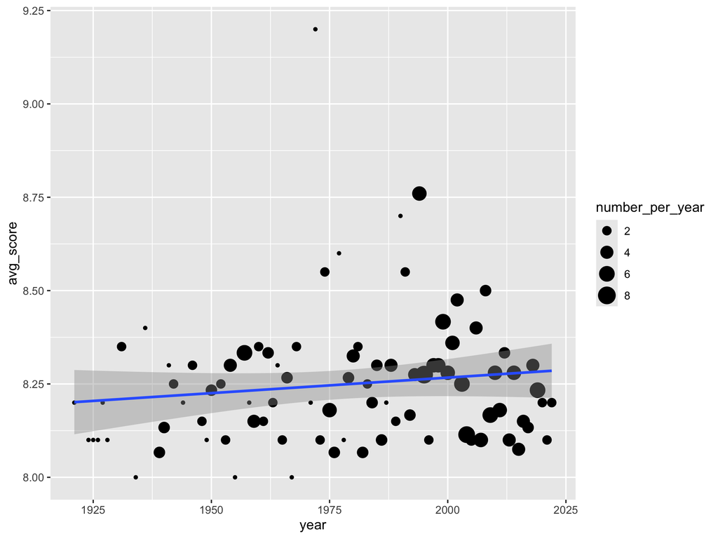

```r
# Find the average score for each year
# Perhaps group by year and take the average score?
imdb_yearly_avg_score <- imdb_top_250  %>%
  group_by(year) %>%
  # Do some more data analysis here
  summarise(avg_score = mean(score),
            number_per_year = n())

# Then plot this with the year on x axis, and average score on the y axis
ggplot(data = imdb_yearly_avg_score,
  aes(x = year,
      y = avg_score)) +
  geom_point(aes(size = number_per_year)) +
  geom_smooth(method = "lm")
```

#### 8. Explore another IMDb table

- Top TV shows: https://web.archive.org/web/20220919144936/https://www.imdb.com/chart/toptv/

Scrap the top 50 TV shows, store them in a similar format to the `imdb_top_250` data, and add the ranks.

```r
imdb_session <- bow("https://web.archive.org/web/20220919144936/https://www.imdb.com/chart/toptv/")

imdb_data <- scrape(imdb_session)

titles <- imdb_data %>%
  html_elements(".titleColumn a") %>%
  html_text2()

years <- imdb_data %>%
  html_elements(".secondaryInfo") %>%
  html_text2() %>%
  # Remove "("
  str_remove("\\(") %>%
  # Remove ")"
  str_remove("\\)") %>%
  as.numeric()

scores <- imdb_data %>%
  html_elements(".imdbRating strong") %>%
  html_text2() %>%
  as.numeric()

imdb_top_tv <- tibble(title = titles,
                      year = years,
                      score = scores) %>%
  # Get the top 50 TV shows
  head(50)


imdb_top_tv
```

```
# A tibble: 50 × 3
   title                        year score
   <chr>                       <dbl> <dbl>
 1 Planet Earth II              2016   9.4
 2 Breaking Bad                 2008   9.4
 3 Planet Earth                 2006   9.4
 4 Band of Brothers             2001   9.4
 5 Chernobyl                    2019   9.3
 6 The Wire                     2002   9.3
 7 Blue Planet II               2017   9.2
 8 Avatar: The Last Airbender   2005   9.2
 9 Cosmos: A Spacetime Odyssey  2014   9.2
10 The Sopranos                 1999   9.2
# ℹ 40 more rows
```

```r
# Add a variable for rank
imdb_top_tv <- imdb_top_tv %>%
  mutate(rank = row_number())

imdb_top_tv
```

```
# A tibble: 50 × 4
   title                        year score  rank
   <chr>                       <dbl> <dbl> <int>
 1 Planet Earth II              2016   9.4     1
 2 Breaking Bad                 2008   9.4     2
 3 Planet Earth                 2006   9.4     3
 4 Band of Brothers             2001   9.4     4
 5 Chernobyl                    2019   9.3     5
 6 The Wire                     2002   9.3     6
 7 Blue Planet II               2017   9.2     7
 8 Avatar: The Last Airbender   2005   9.2     8
 9 Cosmos: A Spacetime Odyssey  2014   9.2     9
10 The Sopranos                 1999   9.2    10
# ℹ 40 more rows
```

#### 9. What were the most popular TV shows in 2015? Hint: use `filter()` and `arrange()`.

```r
imdb_top_tv %>%
  filter(year == 2015) %>%
  arrange(rank)
```

```
# A tibble: 2 × 4
  title             year score  rank
  <chr>            <dbl> <dbl> <int>
1 Better Call Saul  2015   8.9    41
2 TVF Pitchers      2015   8.8    49
```

## Exercise 8B: Introduction to Functions

### 1. Introduction

Functions are often described as “take in some inputs and return some outputs”. They can be used to automate tasks, avoid repeating codes and help abstract away the core parts of the logic.

We’ve used functions previously. For example:

- mean
- median
- min
- max

```r
x <- 1:10
x
```

```
 [1]  1  2  3  4  5  6  7  8  9 10
```

```r
mean(x)
```

```
[1] 5.5
```

```r
median(x)
```

```
[1] 5.5
```

```r
min(x)
```

```
[1] 1
```

```r
max(x)
```

```
[1] 10
```

These functions take in some inputs, and then return some outputs.

Suppose we want to calculate the difference between the minimum and maximum. We can do this:

```r
max(x) - min(x)
```

```
[1] 9
```

But we can give it a more descriptive name, and turn it into a function like:

```r
range_diff <- function(x){
  max(x) - min(x)
}
```

This then takes the same input, and gives us some output:

```r
range_diff(x)
```

```
[1] 9
```

This is one way to write a function.

### 2. Practice creating functions

Using the dataset `mtcars` as an example, try the following:

#### Calculate the difference between the minimum and maximum cylinders using the `range_diff` function we have created above

```r
# Have a look at the variables in cars
mtcars
```

```
                     mpg cyl  disp  hp drat    wt  qsec vs am gear carb
Mazda RX4           21.0   6 160.0 110 3.90 2.620 16.46  0  1    4    4
Mazda RX4 Wag       21.0   6 160.0 110 3.90 2.875 17.02  0  1    4    4
Datsun 710          22.8   4 108.0  93 3.85 2.320 18.61  1  1    4    1
Hornet 4 Drive      21.4   6 258.0 110 3.08 3.215 19.44  1  0    3    1
Hornet Sportabout   18.7   8 360.0 175 3.15 3.440 17.02  0  0    3    2
Valiant             18.1   6 225.0 105 2.76 3.460 20.22  1  0    3    1
Duster 360          14.3   8 360.0 245 3.21 3.570 15.84  0  0    3    4
Merc 240D           24.4   4 146.7  62 3.69 3.190 20.00  1  0    4    2
Merc 230            22.8   4 140.8  95 3.92 3.150 22.90  1  0    4    2
Merc 280            19.2   6 167.6 123 3.92 3.440 18.30  1  0    4    4
Merc 280C           17.8   6 167.6 123 3.92 3.440 18.90  1  0    4    4
Merc 450SE          16.4   8 275.8 180 3.07 4.070 17.40  0  0    3    3
Merc 450SL          17.3   8 275.8 180 3.07 3.730 17.60  0  0    3    3
Merc 450SLC         15.2   8 275.8 180 3.07 3.780 18.00  0  0    3    3
Cadillac Fleetwood  10.4   8 472.0 205 2.93 5.250 17.98  0  0    3    4
Lincoln Continental 10.4   8 460.0 215 3.00 5.424 17.82  0  0    3    4
Chrysler Imperial   14.7   8 440.0 230 3.23 5.345 17.42  0  0    3    4
Fiat 128            32.4   4  78.7  66 4.08 2.200 19.47  1  1    4    1
Honda Civic         30.4   4  75.7  52 4.93 1.615 18.52  1  1    4    2
Toyota Corolla      33.9   4  71.1  65 4.22 1.835 19.90  1  1    4    1
Toyota Corona       21.5   4 120.1  97 3.70 2.465 20.01  1  0    3    1
Dodge Challenger    15.5   8 318.0 150 2.76 3.520 16.87  0  0    3    2
AMC Javelin         15.2   8 304.0 150 3.15 3.435 17.30  0  0    3    2
Camaro Z28          13.3   8 350.0 245 3.73 3.840 15.41  0  0    3    4
Pontiac Firebird    19.2   8 400.0 175 3.08 3.845 17.05  0  0    3    2
Fiat X1-9           27.3   4  79.0  66 4.08 1.935 18.90  1  1    4    1
Porsche 914-2       26.0   4 120.3  91 4.43 2.140 16.70  0  1    5    2
Lotus Europa        30.4   4  95.1 113 3.77 1.513 16.90  1  1    5    2
Ford Pantera L      15.8   8 351.0 264 4.22 3.170 14.50  0  1    5    4
Ferrari Dino        19.7   6 145.0 175 3.62 2.770 15.50  0  1    5    6
Maserati Bora       15.0   8 301.0 335 3.54 3.570 14.60  0  1    5    8
Volvo 142E          21.4   4 121.0 109 4.11 2.780 18.60  1  1    4    2
```

```r
range_diff(mtcars$cyl)
```

```
[1] 4
```

#### Calculate the range of every column in a dataset

**Use a for loop to iterate through the columns**

A `for` loop in R is defined using the `for` keyword, and its basic syntax is:

```r
for (var in seq) {
  expr
}
```

In this structure, `seq` is an iterable object, such as a vector or list, `var` is the variable used to iterate through the sequence, and `expr` represents the code executed during each iteration.

Here’s an example where `i` is the loop variable, and `1:5` is a vector of length 5. During each iteration, `i` takes on the values `1`, `2`, `3`, `4`, and `5`. The `print()` function uses the current value of `i`, resulting in different output being printed with each iteration.

```r
for (i in 1:5) {
  print(i)
}
```

```
[1] 1
[1] 2
[1] 3
[1] 4
[1] 5
```

Similarly, when iterating through a `data.frame` or `tibble`, which are essentially a list under the hood, the loop variable represents each column, which is a vector. Therefore, the `print()` function will output a vector at each iteration. Because there are two columns in `cars`, two vectors will be printed in the example below.

```r
for (i in cars) {
  print(i)
}
```

```
 [1]  4  4  7  7  8  9 10 10 10 11 11 12 12 12 12 13 13 13 13 14 14 14 14 15 15
[26] 15 16 16 17 17 17 18 18 18 18 19 19 19 20 20 20 20 20 22 23 24 24 24 24 25
 [1]   2  10   4  22  16  10  18  26  34  17  28  14  20  24  28  26  34  34  46
[20]  26  36  60  80  20  26  54  32  40  32  40  50  42  56  76  84  36  46  68
[39]  32  48  52  56  64  66  54  70  92  93 120  85
```

Now try to apply the `range_diff()` function to each column of `mtcars` using a for loop.

```r
for (column in mtcars) {
  print(range_diff(column))
}
```

```
[1] 23.5
[1] 4
[1] 400.9
[1] 283
[1] 2.17
[1] 3.911
[1] 8.4
[1] 1
[1] 1
[1] 2
[1] 7
```

**Functional programming**

In R, we can use functional programming tools to apply a function directly to each element of an iterable object. For instance, the base R function `lapply()` takes an iterable object and a function, returning a list of results after applying the function to each element. In the example below, we use an anonymous function on each element of the vector `1:5`. This function takes a value and adds one to it. As a result, `lapply()` returns a list where each element is one greater than the corresponding element in the original vector.

```r
lapply(1:5, function(x) x + 1)
```

```
[[1]]
[1] 2

[[2]]
[1] 3

[[3]]
[1] 4

[[4]]
[1] 5

[[5]]
[1] 6
```

`map()` is a functional programming tool from the `purrr` package with a similar syntax to `lapply()` but offers more flexibility and power. For more details, check out the [purrr cheat sheet](https://github.com/rstudio/cheatsheets/blob/main/purrr.pdf).

In `map()`, an anonymous function can be defined using the formula notation `~`. The expression `~.x + 1` defines the function body, where `.x` represents the input variable. This is equivalent to writing `function(x) x + 1` in `map()`.

```r
map(1:5, ~.x + 1)
```

```
[[1]]
[1] 2

[[2]]
[1] 3

[[3]]
[1] 4

[[4]]
[1] 5

[[5]]
[1] 6
```

You can also use regular functions with both `lapply()` and `map()`. In the following example, each function call produces a list of three elements, where the first element is of length 1, the second is of length 2, and the third is of length 3. This occurs because `rnorm()` is called with inputs `1`, `2`, and `3`, generating random numbers of the specified lengths.

```r
lapply(1:3, rnorm)
```

```
[[1]]
[1] 1.535276

[[2]]
[1] -0.3052341  2.0155357

[[3]]
[1]  0.7151177 -1.5182413  1.3780682
```

```r
map(1:3, rnorm)
```

```
[[1]]
[1] -0.5377559

[[2]]
[1] -0.6560576  0.4616949

[[3]]
[1]  0.5259141  0.9487458 -0.7052061
```

Now try to use `lapply()` or `map()` to apply `range_diff()` on each column of `mtcars`.

```r
lapply(mtcars, range_diff)
```

```
$mpg
[1] 23.5

$cyl
[1] 4

$disp
[1] 400.9

$hp
[1] 283

$drat
[1] 2.17

$wt
[1] 3.911

$qsec
[1] 8.4

$vs
[1] 1

$am
[1] 1

$gear
[1] 2

$carb
[1] 7
```

Notice that `map_dbl()` can convert the resulting list to a numeric vector if all elements in the list are numeric. This function ensures that the output is a vector of numbers. Try it out yourself.

```r
map_dbl(mtcars, range_diff)
```

```
    mpg     cyl    disp      hp    drat      wt    qsec      vs      am    gear
 23.500   4.000 400.900 283.000   2.170   3.911   8.400   1.000   1.000   2.000
   carb
  7.000
```

#### Create your own function to calculate the average number of cylinders without using `mean()`

```r
my_mean <- function(x){
  # This function is only designed for numeric vector.
  if (!is.numeric(x)) stop("Argument `x` is not a numeric vector!")

  # See `?NaN`
  if (length(x) == 0) return(NaN)

  return(sum(x)/length(x))
}

my_mean(mtcars$cyl)
```

```
[1] 6.1875
```

```r
# Compare with the real mean function
mean(mtcars$cyl)
```

```
[1] 6.1875
```

#### Calculate the mean of every column in `mtcars` using the function you created in the last question

```r
map_dbl(mtcars, my_mean)
```

```
       mpg        cyl       disp         hp       drat         wt       qsec
 20.090625   6.187500 230.721875 146.687500   3.596563   3.217250  17.848750
        vs         am       gear       carb
  0.437500   0.406250   3.687500   2.812500
```

## Exercise 8C: Automating scraping with functions

#### 1. Have a look at the three most popular tv shows by scraping the list of most popular TV shows on IMDb: https://web.archive.org/web/20220919144942/https://www.imdb.com/chart/tvmeter/.

The `html_table()` function helps us to extract information from the chart, but the table is quite messy.

```r
tv_url <- "https://web.archive.org/web/20220919144942/https://www.imdb.com/chart/tvmeter/"
tv_data <- bow(tv_url) %>% scrape()

tv_tables <- tv_data %>%
  html_table()
```

Note that the data is in a list and there are 2 empty columns! 🤯 To extract the data, we need to extract the second element of a list.

```r
# Get the clean names
library(janitor)

# Extract the second element of the list
tv_list <- tv_tables[[2]]%>%
  clean_names() %>%
  select(-x,
         -x_2,
         -your_rating) %>%

  # Extract out year
  separate(rank_title,
           into = c("title", "year"),
           sep = "\n") %>%

  # Extract number from year
  mutate(year = parse_number(year))

tv_list
```

```
# A tibble: 100 × 3
   title                                      year im_db_rating
   <chr>                                     <dbl>        <dbl>
 1 House of the Dragon                        2022          8.7
 2 The Lord of the Rings: The Rings of Power  2022          6.9
 3 Cobra Kai                                  2018          8.5
 4 She-Hulk: Attorney at Law                  2022          5
 5 Game of Thrones                            2011          9.2
 6 The Crown                                  2016          8.7
 7 Better Call Saul                           2015          8.9
 8 The Handmaid's Tale                        2017          8.4
 9 Devil in Ohio                              2022          5.9
10 Cyberpunk: Edgerunners                     2022          8.7
# ℹ 90 more rows
```

#### 2. Now, we want to find out more information about each show. So we’re going to make a function to get the title and genre. Let’s first do this for the show “Game of Thrones” from IMDb.

We’ll create a generic function, and pass in the URL for “Game of Thrones”. This way, we can use the same code to get info about any show we want.

```r
got_url <- "https://web.archive.org/web/20220919144942/https://www.imdb.com/title/tt0944947/"  # Game of thrones URL

scrape_show_info <- function(x){

  show <- bow(x) %>% scrape()

  title <- show %>%
    html_elements("h1.sc-b73cd867-0.eKrKux") %>%
    html_text2()

  genres <- show %>%
    html_elements("a.sc-16ede01-3.bYNgQ.ipc-chip.ipc-chip--on-baseAlt") %>%
    html_text2() %>%
    # Put all genres in the format "XXX, XXX, XXX"
    paste(collapse = ", ")

  tibble(title = title, genres = genres)
}

scrape_show_info(got_url)
```

```
# A tibble: 1 × 2
  title           genres
  <chr>           <chr>
1 Game of Thrones Action, Adventure, Drama
```

Hint: An easy way to find the URL you can click on the show from the IMDB website, and use the URL string after the title part for example: ‘https://web.archive.org/web/20220919144942/https://www.imdb.com/title/tt1312171/’

```r
url <- "https://web.archive.org/web/20220919144942/https://www.imdb.com/title/tt1312171/"
scrape_show_info(url)
```

```
# A tibble: 1 × 2
  title                genres
  <chr>                <chr>
1 The Umbrella Academy Action, Adventure, Comedy
```

```r
url <- "https://web.archive.org/web/20220919144942/https://www.imdb.com/title/tt4052886/"
scrape_show_info(url)
```

```
# A tibble: 1 × 2
  title   genres
  <chr>   <chr>
1 Lucifer Crime, Drama, Fantasy
```

```r
url <- "https://web.archive.org/web/20220919144942/https://www.imdb.com/title/tt6905686/"
scrape_show_info(url)
```

```
# A tibble: 1 × 2
  title             genres
  <chr>             <chr>
1 Lovecraft Country Drama, Fantasy, Horror
```

#### 4. What you did in the last question was pretty manual. Rather than looking up the show URL manually, there’s a better way we could do this automatically by scraping the list of shows and extracting the URLs. Then we can use our `scrape_show_info()` function to obtain information about the shows.

```r
urls <- bow("https://web.archive.org/web/20220919144942/http://www.imdb.com/chart/tvmeter") %>%
  scrape() %>%
  html_elements(".titleColumn a") %>%
  # The link is in the attribute `href`
  html_attr("href") %>%
  # Recover the URL
  paste("https://web.archive.org", ., sep = "")
```

Now, scrape the first URL from our `urls` vector.

```r
# Have a look at what's in the urls
urls
```

```
  [1] "https://web.archive.org/web/20220919144942/https://www.imdb.com/title/tt11198330/"
  [2] "https://web.archive.org/web/20220919144942/https://www.imdb.com/title/tt7631058/"
  [3] "https://web.archive.org/web/20220919144942/https://www.imdb.com/title/tt7221388/"
  [4] "https://web.archive.org/web/20220919144942/https://www.imdb.com/title/tt10857160/"
  [5] "https://web.archive.org/web/20220919144942/https://www.imdb.com/title/tt0944947/"
  [6] "https://web.archive.org/web/20220919144942/https://www.imdb.com/title/tt4786824/"
  [7] "https://web.archive.org/web/20220919144942/https://www.imdb.com/title/tt3032476/"
  [8] "https://web.archive.org/web/20220919144942/https://www.imdb.com/title/tt5834204/"
  [9] "https://web.archive.org/web/20220919144942/https://www.imdb.com/title/tt15432016/"
 [10] "https://web.archive.org/web/20220919144942/https://www.imdb.com/title/tt12590266/"
 [11] "https://web.archive.org/web/20220919144942/https://www.imdb.com/title/tt1751634/"
 [12] "https://web.archive.org/web/20220919144942/https://www.imdb.com/title/tt2861424/"
 [13] "https://web.archive.org/web/20220919144942/https://www.imdb.com/title/tt0903747/"
 [14] "https://web.archive.org/web/20220919144942/https://www.imdb.com/title/tt14502728/"
 [15] "https://web.archive.org/web/20220919144942/https://www.imdb.com/title/tt13406094/"
```

[output cut: 85 more lines]

```r
show_info <- scrape_show_info(urls[1])

show_info
```

```
# A tibble: 1 × 2
  title               genres
  <chr>               <chr>
1 House of the Dragon Action, Adventure, Drama
```

#### 6. Let’s use the `map_df()` function to put the results of the `scrape_show_info()` for the first 10 `urls` into a dataframe.

```r
# Just pick 10, because this takes ages to run with the full dataset.
show_info <- map_df(urls[1:10], scrape_show_info)

show_info
```

```
# A tibble: 8 × 2
  title                  genres
  <chr>                  <chr>
1 House of the Dragon    Action, Adventure, Drama
2 Cobra Kai              Action, Comedy, Drama
3 Game of Thrones        Action, Adventure, Drama
4 The Crown              Biography, Drama, History
5 Better Call Saul       Crime, Drama
6 The Handmaid's Tale    Drama, Sci-Fi, Thriller
7 Devil in Ohio          Drama, Horror, Mystery
8 Cyberpunk: Edgerunners Animation, Action, Adventure
```

🥵 Note: Web scraping isn’t always straightforward!